# Die schweigsame Frau

Komische Oper in drei Aufzügen (1935)

Musik von Richard Strauss  
Text von Stefan Zweig nach Ben Jonson

[Tickets](https://staatsoper-berlin.eventim-inhouse.de/webshop/webticket/shop?language=de&production=1206)

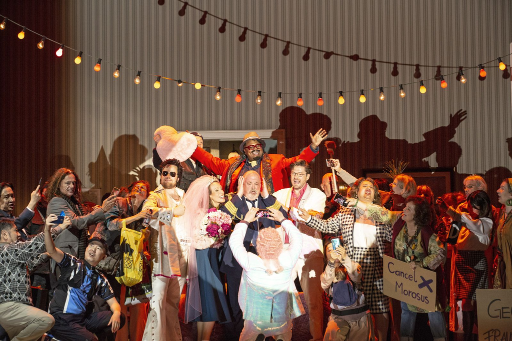

Für Richard Strauss, auf die Siebzig zugehend, war es ein Glücksfall, als zu Beginn der 1930er Jahre der renommierte Literat Stefan Zweig, bekannt durch seine kunstreichen, gedankentiefen Romane, Novellen und Theaterstücke, sich als sein neuer Librettist empfahl. In wechselseitig inspirierender Zusammenarbeit schufen sie, nach einer Komödie von Ben Jonson aus der Shakespeare-Zeit, eine wahrhaft „komische Oper“ voller markanter Charaktere, Tempo und Witz, aber auch von großer Nachdenklichkeit. „Die Oper ist ein Volltreffer, wenn vielleicht erst im 21. Jahrhundert“, so Strauss selbst, dem in schwieriger, dunkler Zeit ein Werk von hoher kompositorischer Virtuosität und gelöster Heiterkeit gelang, eine Geschichte von Menschen, die sich nach Ruhe sehnen oder sich in Geschäftigkeit ergehen. Regisseur Jan Philipp Gloger debütiert damit an der Staatsoper – und für Christian Thielemann ist es die erste Neuproduktion als Generalmusikdirektor des Hauses, ein Amt, das einst auch Strauss bekleidet hatte.

Zum letzten Mal in dieser Spielzeit

Donnerstag, 24. Juli 2025  
19.00 Uhr

[Staatsoper Unter den Linden](https://www.staatsoper-berlin.de/de/ihr-besuch/anfahrt/staatsoper-unter-den-linden.35/)

[Tickets](https://staatsoper-berlin.eventim-inhouse.de/webshop/webticket/shop?language=de&event=18230)

Dauer: ca. 3:40 h inklusive zweier Pausen

Sprache: In deutscher Sprache mit deutschen und englischen Übertiteln

Altersempfehlung: ab 14 Jahren

Vorwort 45 Minuten vor Vorstellungsbeginn im Apollosaal

## Besetzung

- Musikalische Leitung:

  [Christian Thielemann](https://www.staatsoper-berlin.de/de/kuenstler/christian-thielemann.3157/)
- Inszenierung:

  [Jan Philipp Gloger](https://www.staatsoper-berlin.de/de/kuenstler/jan-philipp-gloger.3479/)
- Spielleitung:
  - [Tabatha McFadyen](https://www.staatsoper-berlin.de/de/kuenstler/tabatha-mcfadyen.3591/),
  - [Caroline Staunton](https://www.staatsoper-berlin.de/de/kuenstler/caroline-staunton.3218/)
- Bühne:

  [Ben Baur](https://www.staatsoper-berlin.de/de/kuenstler/ben-baur.3480/)
- Kostüme:

  [Justina Klimczyk](https://www.staatsoper-berlin.de/de/kuenstler/justina-klimczyk.3481/)
- Licht:

  Tobias Krauß
- Video:

  Leonard Wölfl
- Choreographie:

  Florian Hurler
- Einstudierung Chor:

  [Dani Juris](https://www.staatsoper-berlin.de/de/kuenstler/dani-juris.3290/)
- Dramaturgie:

  [Detlef Giese](https://www.staatsoper-berlin.de/de/kuenstler/detlef-giese.1014/)
- Sir Morosus:

  [Peter Rose](https://www.staatsoper-berlin.de/de/kuenstler/peter-rose.1887/)
- Seine Haushälterin:

  [Iris Vermillion](https://www.staatsoper-berlin.de/de/kuenstler/iris-vermillion.3478/)
- Barbier Schneidebart:

  [Samuel Hasselhorn](https://www.staatsoper-berlin.de/de/kuenstler/samuel-hasselhorn.2963/)
- Henry Morosus:

  [Siyabonga Maqungo](https://www.staatsoper-berlin.de/de/kuenstler/siyabonga-maqungo.2392/)
- Aminta, seine Gattin:

  [Brenda Rae](https://www.staatsoper-berlin.de/de/kuenstler/brenda-rae.1520/)
- Isotta:

  [Serafina Starke](https://www.staatsoper-berlin.de/de/kuenstler/serafina-starke.3449/)
- Carlotta:

  [Rebecka Wallroth](https://www.staatsoper-berlin.de/de/kuenstler/rebecka-wallroth.3275/)
- Morbio:

  [Dionysios Avgerinos](https://www.staatsoper-berlin.de/de/kuenstler/dionysios-avgerinos.3277/)
- Vanuzzi:

  [Manuel Winckhler](https://www.staatsoper-berlin.de/de/kuenstler/manuel-winckhler.3435/)
- Farfallo:

  [Friedrich Hamel](https://www.staatsoper-berlin.de/de/kuenstler/friedrich-hamel.3015/)
- - [Staatsopernchor](https://www.staatsoper-berlin.de/de/kuenstler/staatsopernchor.1020/),
  - [Staatskapelle Berlin](https://www.staatsoper-berlin.de/de/kuenstler/staatskapelle-berlin.1019/)